```python
from thinkdsp import *
import numpy as np
import matplotlib.pyplot as plt
```

# Лабораторная работа 6

### Упражнение 6.1

> В этой главе утверждается, что `analyze1` требует времени пропорционально $n^3$, а `analyze2` - пропорционально $n^2$. Убедитесь в этом, запуская их с несколькими разными массивами и засекая время работы. Используйте команду %timeit

```python
from thinkdsp import UncorrelatedGaussianNoise

signal = UncorrelatedGaussianNoise()
noise = signal.make_wave(duration=1.0, framerate=16384)
```

Начнем с генерации сигнала белого шума

```python
PI2 = np.pi * 2

def analyze1(ys, fs, ts):
    args = np.outer(ts, fs)
    M = np.cos(PI2 * args)
    amps = np.linalg.solve(M, ys)
    return amps
```

```python
from scipy.stats import linregress

loglog = dict(xscale='log', yscale='log')

def plot_bests(ns, bests):
    plt.plot(ns, bests)
    decorate(**loglog)

    x = np.log(ns)
    y = np.log(bests)
    t = linregress(x,y)
    slope = t[0]

    return slope
```

Фукнкция для построения графика в логарифмическом масштабе и вычисления коэффициента наклона построеной прямой

```python
def run_speed_test(ns, func):
    results = []
    for N in ns:
        print(N)
        ts = (0.5 + np.arange(N)) / N
        freqs = (0.5 + np.arange(N)) / 2
        ys = noise.ys[:N]
        result = %timeit -r1 -o func(ys, freqs, ts)
        results.append(result)

    bests = [result.best for result in results]
    return bests
```

Функция для замера времени работы функции вычисления амплитуд.

```python
ns = 2 ** np.arange(6, 14)
ns
```

```
array([  64,  128,  256,  512, 1024, 2048, 4096, 8192], dtype=int32)
```

```
64
81.5 µs ± 0 ns per loop (mean ± std. dev. of 1 run, 10,000 loops each)
128
278 µs ± 0 ns per loop (mean ± std. dev. of 1 run, 1,000 loops each)
256
1.5 ms ± 0 ns per loop (mean ± std. dev. of 1 run, 1,000 loops each)
512
8.52 ms ± 0 ns per loop (mean ± std. dev. of 1 run, 100 loops each)
1024
40.7 ms ± 0 ns per loop (mean ± std. dev. of 1 run, 10 loops each)
2048
194 ms ± 0 ns per loop (mean ± std. dev. of 1 run, 10 loops each)
4096
923 ms ± 0 ns per loop (mean ± std. dev. of 1 run, 1 loop each)
8192
4.65 s ± 0 ns per loop (mean ± std. dev. of 1 run, 1 loop each)
```

```
2.2903340406224615
```

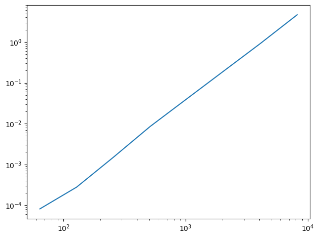

```python
bests = run_speed_test(ns, analyze1)
plot_bests(ns, bests)
```

По итогам тестирования `analyze1` получили коэффициент наклона равный 2.3, а ожидали 3. Это может быть связано с тем, что на малых размерах массивов сложность равна $n^2$

```python
def analyze2(ys, fs, ts):
    args = np.outer(ts, fs)
    M = np.cos(PI2 * args)
    amps = np.dot(M, ys) / 2
    return amps
```

```
64
47.9 µs ± 0 ns per loop (mean ± std. dev. of 1 run, 10,000 loops each)
128
171 µs ± 0 ns per loop (mean ± std. dev. of 1 run, 10,000 loops each)
256
690 µs ± 0 ns per loop (mean ± std. dev. of 1 run, 1,000 loops each)
512
4.9 ms ± 0 ns per loop (mean ± std. dev. of 1 run, 100 loops each)
1024
18 ms ± 0 ns per loop (mean ± std. dev. of 1 run, 10 loops each)
2048
61.4 ms ± 0 ns per loop (mean ± std. dev. of 1 run, 10 loops each)
4096
242 ms ± 0 ns per loop (mean ± std. dev. of 1 run, 1 loop each)
8192
971 ms ± 0 ns per loop (mean ± std. dev. of 1 run, 1 loop each)
```

```
2.0691057950467195
```

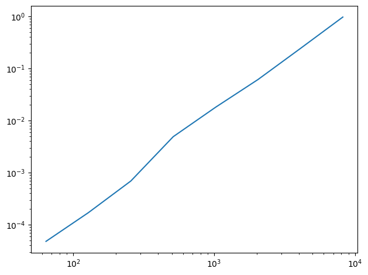

```python
bests2 = run_speed_test(ns, analyze2)
plot_bests(ns, bests2)
```

Результаты для `analyze2` образуют почти прямую линию с коэффициентом наклона 2

```python
import scipy.fftpack

def scipy_dct(ys, freqs, ts):
    return scipy.fftpack.dct(ys, type=3)
```

```
64
6.53 µs ± 0 ns per loop (mean ± std. dev. of 1 run, 100,000 loops each)
128
7.03 µs ± 0 ns per loop (mean ± std. dev. of 1 run, 100,000 loops each)
256
7.34 µs ± 0 ns per loop (mean ± std. dev. of 1 run, 100,000 loops each)
512
8.31 µs ± 0 ns per loop (mean ± std. dev. of 1 run, 100,000 loops each)
1024
12.1 µs ± 0 ns per loop (mean ± std. dev. of 1 run, 100,000 loops each)
2048
15.3 µs ± 0 ns per loop (mean ± std. dev. of 1 run, 100,000 loops each)
4096
26.7 µs ± 0 ns per loop (mean ± std. dev. of 1 run, 10,000 loops each)
8192
50.3 µs ± 0 ns per loop (mean ± std. dev. of 1 run, 10,000 loops each)
```

```
0.40423522550639285
```

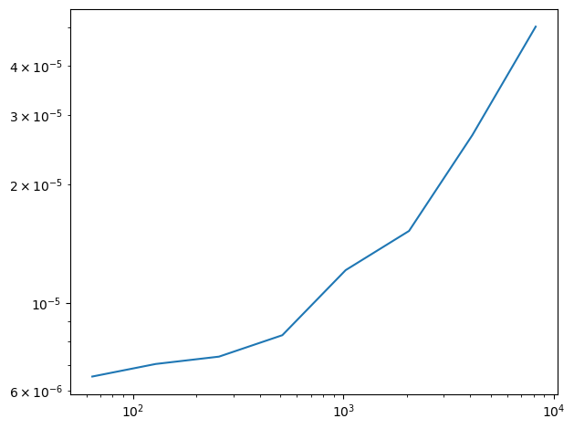

```python
bests3 = run_speed_test(ns, scipy_dct)
plot_bests(ns, bests3)
```

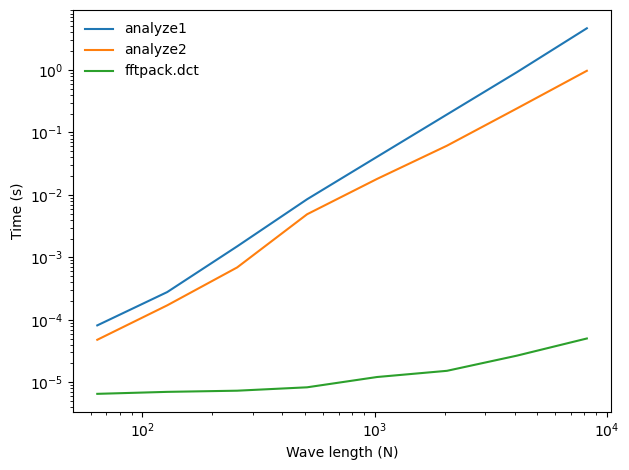

```python
plt.plot(ns, bests, label='analyze1')
plt.plot(ns, bests2, label='analyze2')
plt.plot(ns, bests3, label='fftpack.dct')
decorate(xlabel='Wave length (N)', ylabel='Time (s)', **loglog)
```

### Упражнение 6.2

> Одно из основных применений ДКП - это сжатие звука и изображений. В простейшей форме ДКП при сжатии работает следующим образом:
> 1. Разбивает длинный сигнал на сегменты
> 2. Вычисляет ДКП каждого сегмента
> 3. Определяет частотные компоненты с такой амплитудой, что их не слышно, и удаляет их, сохраняя только оставшиеся частоты и амплитуды.
> 4. При воспроизведении сигнала загружает частоты и амплитуды каждого сегмента и применяет обратное ДКП

> Реализуйте версию этого алгоритма и примените его для записи музыки или речи. Сколько компонент можно удалить до того, как разнрица станет заметной?  
> Для того, чтобы этот метод стал практичным, нужен способ хранения прореженного массива, то есть массива, где большинство элементов равно нулю

```python
from thinkdsp import read_wave

wave = read_wave('100475__iluppai__saxophone-weep.wav')
wave.make_audio()
```

[interactive chart not shown]

```python
segment = wave.segment(start=1, duration=0.5)
segment.normalize()
segment.make_audio()
```

[interactive chart not shown]

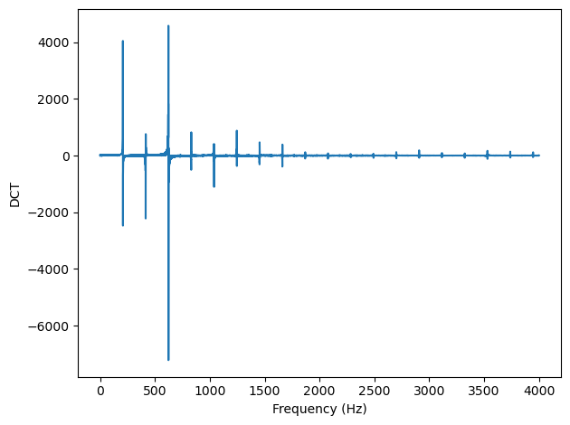

```python
seg_dct = segment.make_dct()
seg_dct.plot(high=4000)
decorate(xlabel='Frequency (Hz)', ylabel='DCT')
```

В сегменте только несколько компонент с достаточно большой амплитудой, а остальные компоненты близки к нулю. Будем убирать эти компоненты.

```python
def compress(dct, thresh=1):
    count = 0
    for i, amp in enumerate(dct.amps):
        if np.abs(amp) < thresh:
            dct.hs[i] = 0
            count += 1

    n = len(dct.amps)
    print(count, n, 100 * count / n, sep='\t')
```

Функция `compress` делает равными нулю компоненты, меньшие предельного значения амплитуды. Она выводит количество обнуленных компонент и все число элементов.

```
20292	22050	92.02721088435374
```

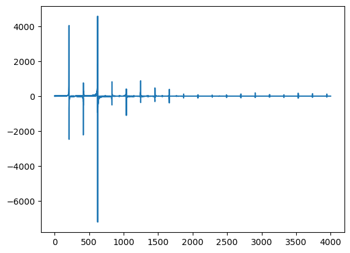

```python
compress(seg_dct, thresh=10)
seg_dct.plot(high=4000)
```

Как мы видим было обнулено 92% всех компонент.

```python
seg2 = seg_dct.make_wave()
seg2.make_audio()
```

[interactive chart not shown]

И звук сегмента не изменился

```python
from thinkdsp import Spectrogram

def make_dct_spectrogram(wave, seg_length):
    window = np.hamming(seg_length)
    i, j = 0, seg_length
    step = seg_length // 2

    # map from time to Spectrum
    spec_map = {}

    while j < len(wave.ys):
        segment = wave.slice(i, j)
        segment.window(window)

        # the nominal time for this segment is the midpoint
        t = (segment.start + segment.end) / 2
        spec_map[t] = segment.make_dct()

        i += step
        j += step

    return Spectrogram(spec_map, seg_length)
```

Функция для вычисления спектрограммы с использованием ДКТ. Затем мы можем применить фунцию сжатия к каждому сенменту спектрограммы.

```python
spectro = make_dct_spectrogram(wave, seg_length=1024)
for t, dct in sorted(spectro.spec_map.items()):
    compress(dct, thresh=0.2)
```

```
1018	1024	99.4140625
1016	1024	99.21875
1014	1024	99.0234375
1017	1024	99.31640625
1016	1024	99.21875
1017	1024	99.31640625
1016	1024	99.21875
1020	1024	99.609375
1014	1024	99.0234375
1005	1024	98.14453125
1009	1024	98.53515625
1015	1024	99.12109375
1015	1024	99.12109375
1016	1024	99.21875
1016	1024	99.21875
1015	1024	99.12109375
1017	1024	99.31640625
1020	1024	99.609375
1013	1024	98.92578125
1017	1024	99.31640625
1013	1024	98.92578125
1017	1024	99.31640625
1018	1024	99.4140625
1015	1024	99.12109375
1013	1024	98.92578125
794	1024	77.5390625
785	1024	76.66015625
955	1024	93.26171875
995	1024	97.16796875
992	1024	96.875
976	1024	95.3125
925	1024	90.33203125
802	1024	78.3203125
836	1024	81.640625
850	1024	83.0078125
882	1024	86.1328125
883	1024	86.23046875
891	1024	87.01171875
901	1024	87.98828125
902	1024	88.0859375
```

[output cut: 955 more lines]

```
1012	1024	98.828125
1014	1024	99.0234375
1016	1024	99.21875
1010	1024	98.6328125
1014	1024	99.0234375
1015	1024	99.12109375
1012	1024	98.828125
1019	1024	99.51171875
1015	1024	99.12109375
1016	1024	99.21875
1019	1024	99.51171875
1019	1024	99.51171875
1016	1024	99.21875
1018	1024	99.4140625
1018	1024	99.4140625
```

```python
wave2 = spectro.make_wave()
wave2.make_audio()
```

[interactive chart not shown]

Эффект сжатия заметен. При воспроизведении звука можем услышать небольшой шум